# Well water salinity in Charlestown, Rhode Island

Jeeban Panthi, Thomas Boving, Soni M Pradhanang

2018-05-11

# Introduction

Provate well water quality data for the Charlestown area were collected by the town office (http://www.charlestownri.org/) since 2008. There are many water quality parameters, but for this project I’m analyzing the indicators of salinity (EC and TDS). For the confidential purpose, the GIS points have been modified from the original datasets.

## Global Options

```r
knitr::opts_chunk$set(echo = TRUE, warning=FALSE, message=FALSE,
                      fig.width=12, fig.height=8, fig.path='figs/')
```

## Required R packages

```r
library(tidyverse)
library(ggplot2)
library(lubridate)
library(gridExtra)
library(dplyr)
library(ggpubr)
library(Hmisc)
library(readxl)
library(rgdal)
library(gstat)
library(sp)
library(raster)
library(mapview)
library(sf)
```

## Reading Data

```r
water <- read_excel("~/Desktop/bio/project/water.xlsx", na = " ") %>%
  mutate_at(vars(Nitrite:VOC), as.numeric)
```

### Study site

```r
charlestown_bnd <- st_read("~/Desktop/bio/project/Municipalities_1997/Municipalities_1997.shp") %>%
  filter(NAME == "CHARLESTOWN") %>%
  st_transform(crs = "+proj=utm +zone=19 +ellps=WGS84 +datum=WGS84 +no_defs") %>%
  as("Spatial")
```

```r
water_sp <- SpatialPoints(water[,c("Long","Lat")], proj4string = CRS("+proj=longlat +datum=WGS84"))
water_sp <- SpatialPointsDataFrame(water_sp, water)
water_sp <- spTransform(water_sp, CRS(proj4string(charlestown_bnd)))
mapview(water_sp) + charlestown_bnd
```

[interactive chart not shown]

Charlestown, as shown in above map is a municipality in southern part of Rhode Island. Blue circles on the map indicate the well water sampling locations. You can click on the layer icon on the top left of the map to add different base maps.

# Plots

### 1. Number of water samples collected every year

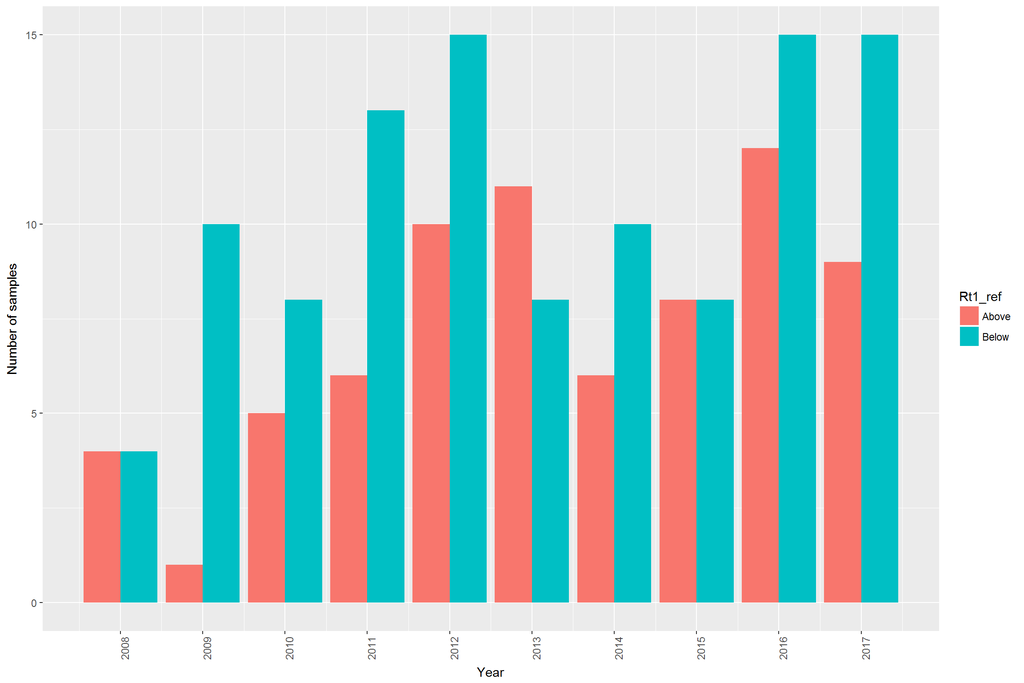

```r
ggplot(water) + stat_count(aes(x = Year, fill =Rt1_ref ), position = "dodge")+ylab('Number of samples')+xlab('Year')+theme(axis.text.x = element_text(angle = 90))+scale_x_continuous(breaks=seq(2008, 2017, 1))
```

Figure 1: Number of water samples collected every year from the study area

The starting year is 2008 and the data goes until 2017. In recent years, the number of samples is increasing in general.

### 2. Total dissolved solids value in below and above the route 1 road

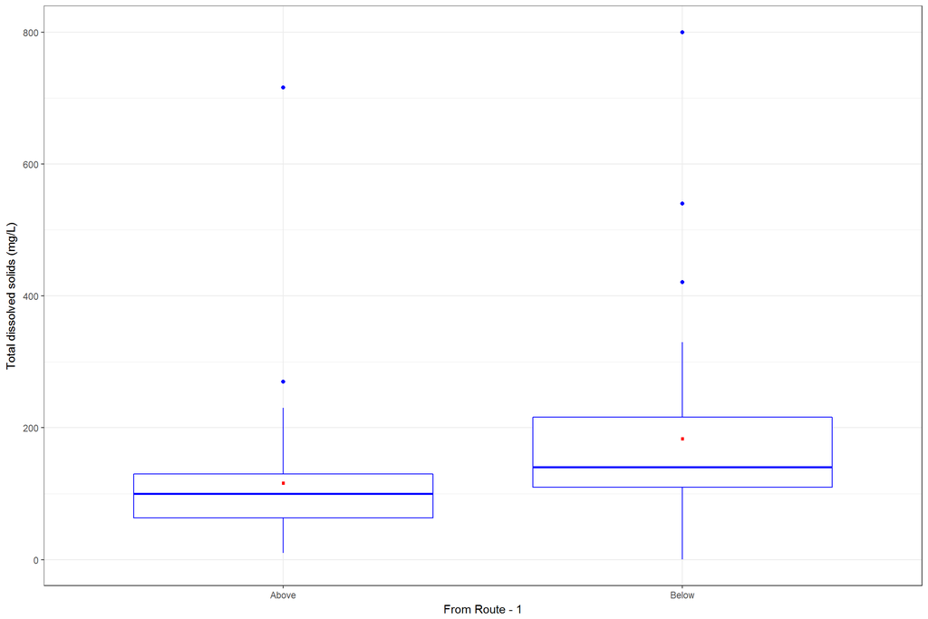

```r
ggplot(water, aes(x=Rt1_ref, y=TDS))+ geom_boxplot(alpha = 1,color='blue')+xlab('From Route - 1')+ylab('Total dissolved solids (mg/L)')+  stat_summary(fun.y=mean, color="red", geom="point", shape=15, size=1,show_guide = T, show.legend = T) + theme_bw()
```

Figure 2: TDS level below and above Route-1 highway

### 3. Monthly avarage value of TDS

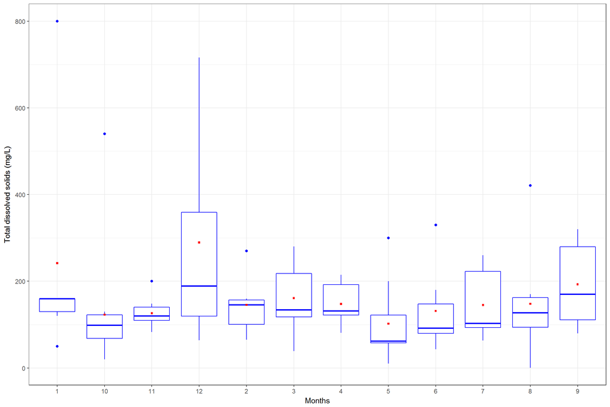

```r
water$Month<-as.character(as.numeric(water$Month))
ggplot(water, aes(x=Month, y=TDS))+ geom_boxplot(alpha = 1,color='blue')+xlab('Months')+ylab('Total dissolved solids (mg/L)')+ stat_summary(fun.y=mean, color="red", geom="point", shape=15, size=1,show_guide = T, show.legend = T) + theme_bw()
```

Figure 3: Seasonal variation in TDS value

### 4. Yearly avarage value of TDS

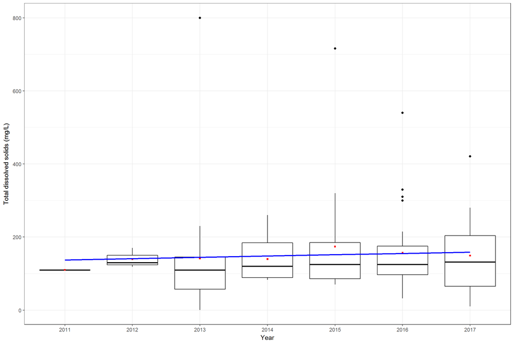

```r
water$Year<-as.character(as.numeric(water$Year))
water_2010<-water[ which(water$Year>2010),]
ggplot(water_2010, aes(x=Year, y=TDS))+ geom_boxplot(alpha = 1,color='black')+xlab('Year')+ylab('Total dissolved solids (mg/L)')+ stat_summary(fun.y=mean, color="red", geom="point", shape=15, size=1,show_guide = T, show.legend = T) + theme_bw()+geom_smooth(method="lm", se=FALSE, color="blue", aes(group=1))
```

Figure 4: Yearly variation of total dissolved solids.

It shows that the annual TDS values does not show any significant trend.

### 5. Relationship between TDS and Chloride

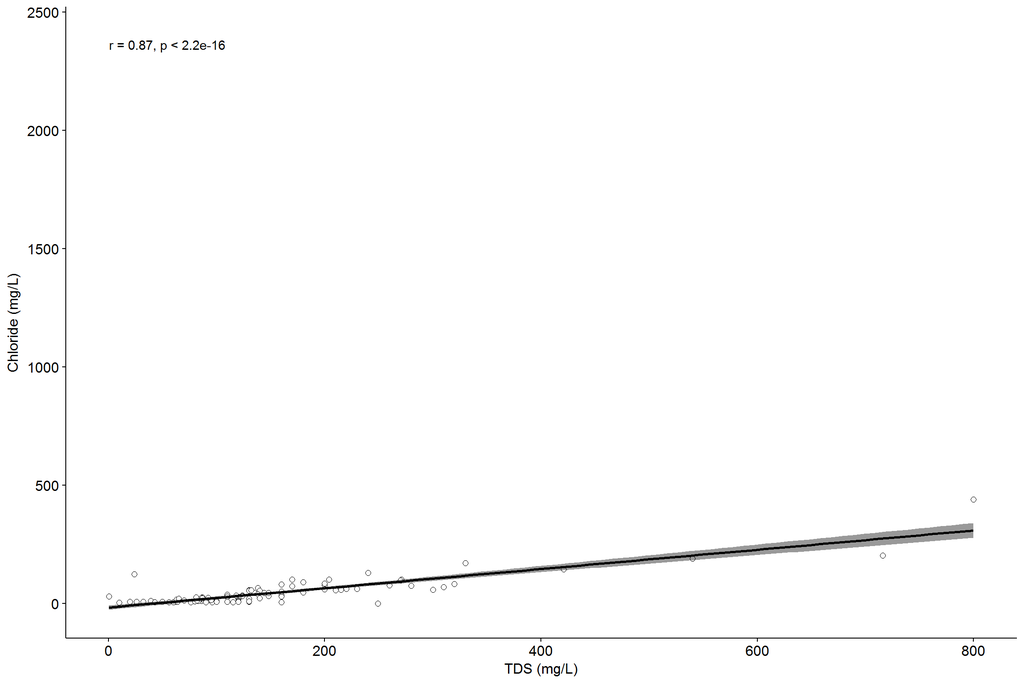

```r
ggscatter(water, x = "TDS", y = "Chloride", color = "black", shape = 21, size = 2, add = "reg.line", conf.int = TRUE, cor.coef = TRUE, cor.method = "pearson",  ylab = "Chloride (mg/L)", xlab = "TDS (mg/L)")
```

```r
c4 <- cor.test(water$EC,water$Chloride)
```

### 6. Relationship between TDS and Coliform present

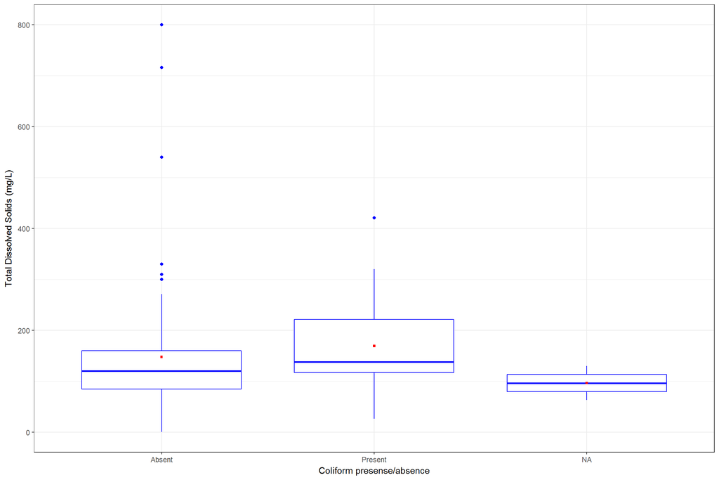

```r
ggplot(water, aes(x=Coliform, y=TDS))+
  geom_boxplot(alpha = 1,color='blue')+xlab('Coliform presense/absence')+ylab('Total Dissolved Solids (mg/L)')+ stat_summary(fun.y=mean, color="red", geom="point", shape=15, size=1,show_guide = T, show.legend = T) + theme_bw()
```

Figure 6: TDS value and Coliform present relationship.

The TDS value is high where the coliform is present. It signals that the wells were contaminated anthropogenically therefore coliform and higher salinity was found.